# Overfitting

Varun Boodram

December 28, 2015

Often overfitting is assosciated with large values of $\hat{w}$. To see this, we simulate 30 points of data drawn from the sinusoid function $y=sin(4x)$

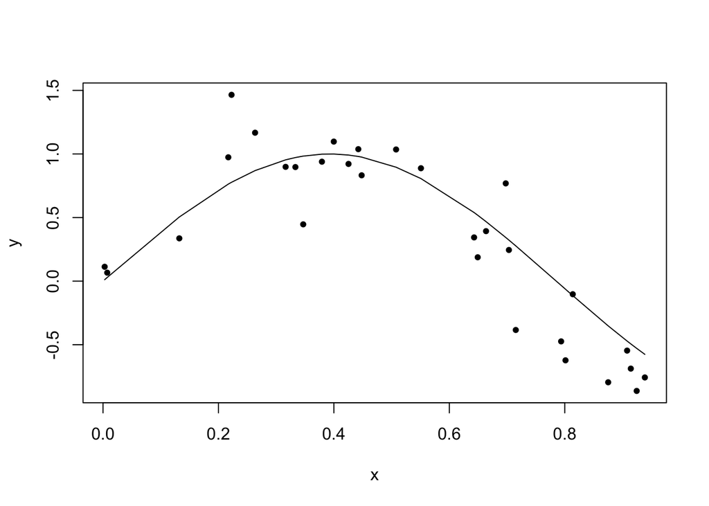

```r
rm(list = ls())
set.seed(98013)
# create a random sample of 30 numbers in the interval [0,1)
x <- sort(runif(n = 30, min = 0, max = 1))
# evaluate y at each point x
y <- sin(4*x)
# add noise
e <- rnorm(30, 0, 1/3)
y <- y+e
# put into a data frame
data <- data.frame(x, y)
# visualise the data
plot(x = x, y = y, pch =20)
lines(x = x, y <- sin(4*x))
```

The true trend is of course, the sin function, and the black dots are the observed values.

##### Define some useful polynomial regression functions.

We define a function to create feautres for polynomial regression models of any degree.

```r
## poly_dataframe() accepts as input a data frame, a feature (the name of a single column in that data frame, wrapped in " "), and a degree, and returns a data frame whose consecutive columns are powers of the values of the feature, in increasing order up to the value of the entered degree
poly_dataframe <- function(dataframe, output, feature, degree){
        poly <- matrix(nrow = nrow(dataframe), ncol = degree)
        names<-vector()
        if (degree == 1){
                poly[,1] <- dataframe[[feature]]
                poly <- as.data.frame(poly)
                colnames(poly) <- "power_1"
        } else {
                columns <- vector()
                for (i in 1: degree){
                        names[i] <- paste("power_", i, sep = "")
                        poly[, i] <- dataframe[[feature]]^i
                        poly <- as.data.frame(poly)
                        colnames(poly) <- names
                        }
        }
        poly <-cbind(dataframe[[output]], poly)
        colnames(poly)[1]<-"output"
        poly
}
```

Define a function to fit a polynomial linear regression model to the degree in data

```r
polyfit<-function(dataframe, output, feature, degree){
  data <- poly_dataframe(dataframe = dataframe,
                         output = output,
                         feature = feature,
                         degree = degree)
  fit <- lm(formula = output~., data = data)
  plot(x = data$power_1,
       y = data$output,
       pch=20,
       xlab = "x",
       ylab = "y",
       main = paste("Degree", degree, "fit"))
  lines(x = x, y <- sin(4*x))
  points(dataframe[[feature]],
         fitted(fit),
         type ="l",
         col ="red",
         lwd =3)
  print(fit$coefficients)
}
```

##### Fit polynomials of differing degrees and examine the coefficients

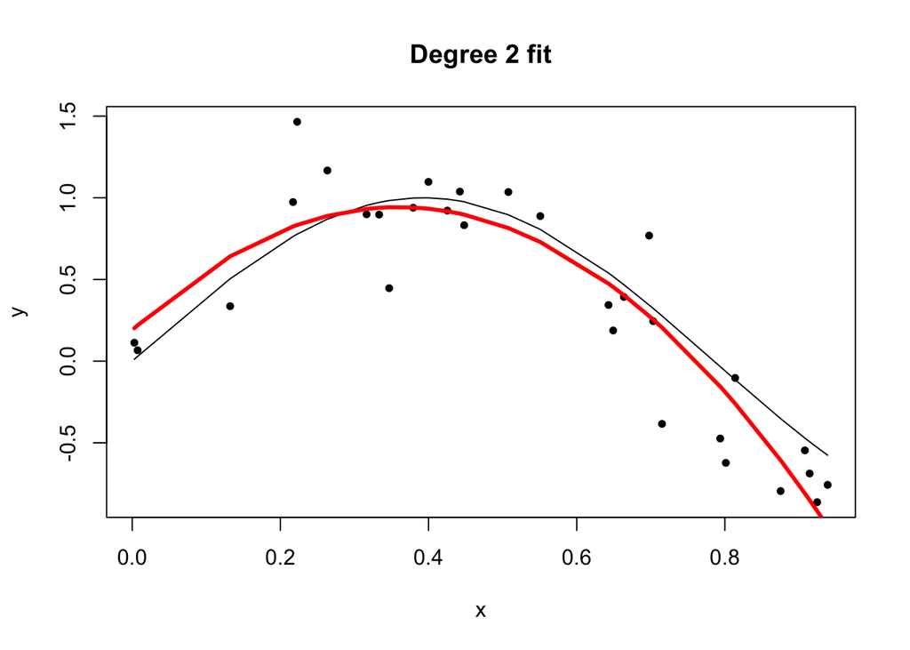

```
## (Intercept)     power_1     power_2
##   0.1897783   4.1884349  -5.8248738
```

```r
polyfit(dataframe = data, output = "y", feature = "x", degree = 2)
```

The slopes and intercepts are numbers that we can easily understand: they are relatively small.

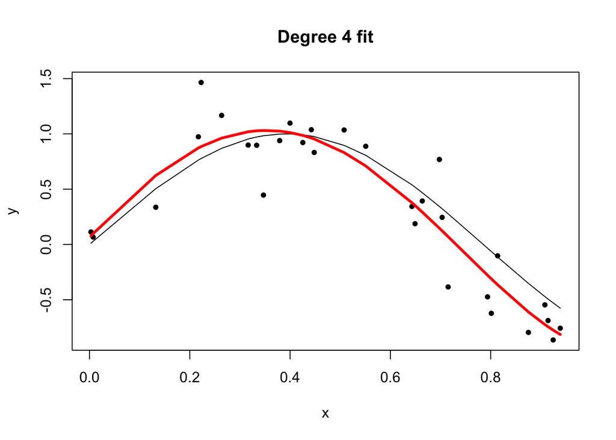

```
##  (Intercept)      power_1      power_2      power_3      power_4
##   0.06396487   4.78517956  -2.75588552 -11.65538031   8.62815077
```

```r
polyfit(dataframe = data, output = "y", feature = "x", degree = 4 )
```

Either because the `lm()` library is optimized to handle situations like this, or because the inital conditions of my plot were different from those in the lecture, the increase in the coefficients is not as dramatic as it is in the demo.

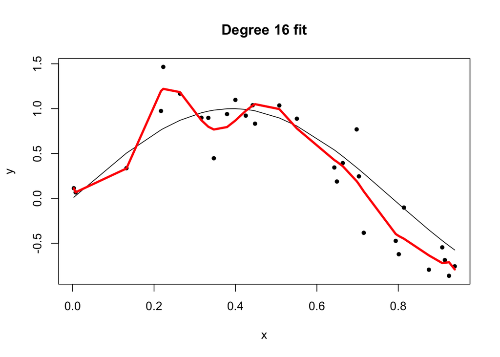

```
##   (Intercept)       power_1       power_2       power_3       power_4
##  1.607693e-01 -2.045760e+01  1.228028e+03 -2.635753e+04  2.747766e+05
##       power_5       power_6       power_7       power_8       power_9
## -1.528672e+06  4.527850e+06 -5.056700e+06 -1.045809e+07  4.935221e+07
##      power_10      power_11      power_12      power_13      power_14
## -8.516428e+07  7.744188e+07 -3.309733e+07            NA  4.220714e+06
##      power_15      power_16
##            NA -4.872234e+05
```

```r
polyfit(dataframe = data, output = "y", feature = "x", degree = 16 )
```

Ridge regression will quantify overfitting through a measure of the absolute values of the coefficients.

##### Overfitting of linear models more generically

Overfitting is not specific to polynomial regression, but is something that we often observe in more complex models, such as when we have lots of inputs. If we fit a model for house prices on a large number of inputs (# bathrooms, # bedrooms, lot size, year built, etc), the resulting model has a lot of flexibility to explain the output.

Or more generically, we can say that if we have lots of features, a large $D$ in the expression $y_i=\Sigma_{i=1}^D \textbf{w}_jh_j(\textbf{x}_i)+\epsilon_i$

that is, when we have lots of functions of our inputs, the model is subject to becomming overfit.

Ridge Regression aims to avoid overfitting by adding a cost to the RSS term of standard least squares that depends on the 2-norm of the of the coefficients, $\Vert w \Vert_2^2$. The result is penalizing fits with large coefficients. The strength of this penalty, and hence the fit vs. model complexity is is controlled by the parameter $\lambda$.

```r
library(ridge)
ridgefit<-function(dataframe, output, feature, degree, l2_penalty){
  data <- poly_dataframe(dataframe = dataframe,
                         output = output,
                         feature = feature,
                         degree = degree)
  fit <- linearRidge(formula = output~., data = data, lambda = l2_penalty)
  plot(x = data$power_1,
       y = data$output,
       pch=20,
       xlab = "x",
       ylab = "y",
       main = paste("Degree", degree, "fit"))
  lines(x = x, y <- sin(4*x))
  points(dataframe[[feature]],
         predict(fit),
         type ="l",
         col ="red",
         lwd =3)
  print(coef(fit))
}
```

With a very small penalty: we expect the plot to look just like the least squares case

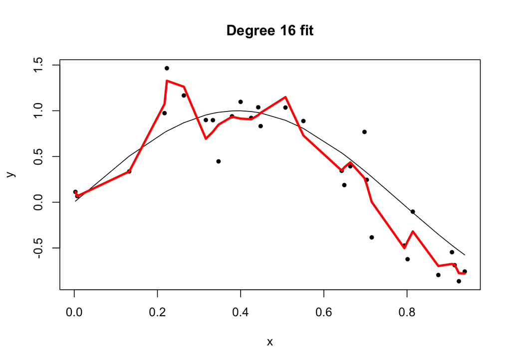

```
##   (Intercept)       power_1       power_2       power_3       power_4
##  6.246683e+00 -3.213527e+03  4.014739e+05 -1.160091e+07  1.651650e+08
##       power_5       power_6       power_7       power_8       power_9
## -1.433554e+09  8.365604e+09 -3.462224e+10  1.047880e+11 -2.358071e+11
##      power_10      power_11      power_12      power_13      power_14
##  3.969090e+11 -4.978753e+11  4.586996e+11 -3.013397e+11  1.335867e+11
##      power_15      power_16
## -3.580805e+10  4.383071e+09
```

```r
ridgefit(dataframe = data, output = "y", feature = "x", degree = 16, l2_penalty = 1e-25)
```

With a very large penalty:

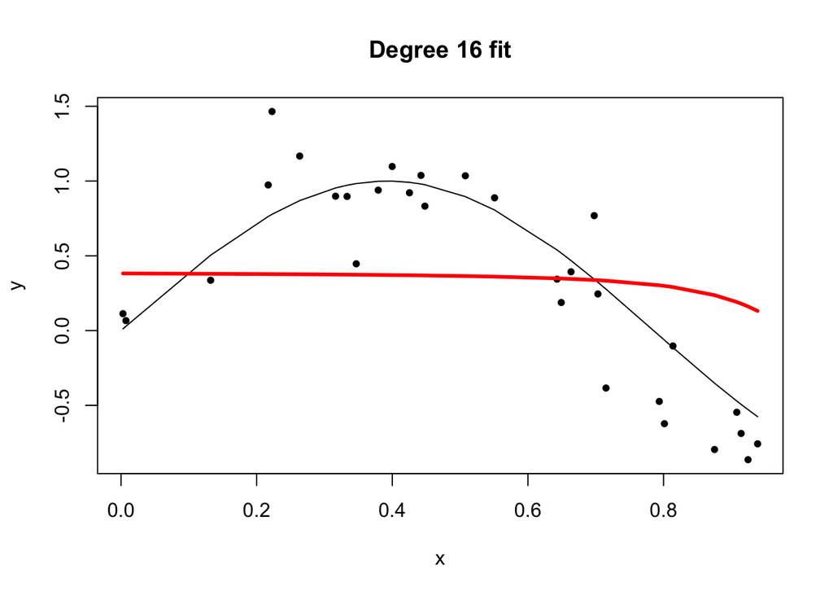

```
## (Intercept)     power_1     power_2     power_3     power_4     power_5
##  0.38220519 -0.01496566 -0.01731289 -0.01908541 -0.02069689 -0.02219452
##     power_6     power_7     power_8     power_9    power_10    power_11
## -0.02363228 -0.02506498 -0.02653743 -0.02808281 -0.02972504 -0.03148183
##    power_12    power_13    power_14    power_15    power_16
## -0.03336700 -0.03539221 -0.03756794 -0.03990423 -0.04241099
```

```r
ridgefit(dataframe = data, output = "y", feature = "x", degree = 16, l2_penalty = 100)
```

The coefficients are very, very small. The fit is a really, really smooth curve, which is really way too simple a description of what is going on in the data (it is underfit).

Plotting the resluting fit over a variety of $\lambda$s:

```r
penalties <-c(1e-25, 1e-10, 1e-6, 1e-3, 1e2)
for (i in 1: length(penalties)){
  l2_penalty<-penalties[i]
  ridgefit(dataframe = data, output = "y", feature = "x", degree = 16, l2_penalty = l2_penalty)
}
```

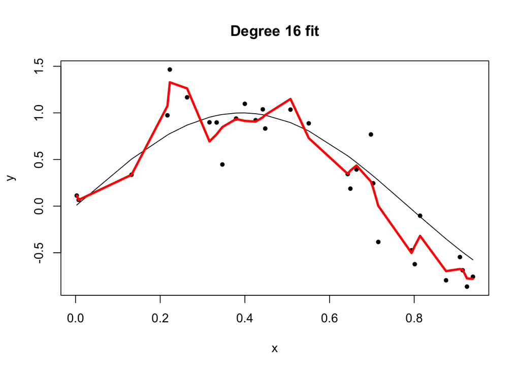

```
##   (Intercept)       power_1       power_2       power_3       power_4
##  6.246683e+00 -3.213527e+03  4.014739e+05 -1.160091e+07  1.651650e+08
##       power_5       power_6       power_7       power_8       power_9
## -1.433554e+09  8.365604e+09 -3.462224e+10  1.047880e+11 -2.358071e+11
##      power_10      power_11      power_12      power_13      power_14
##  3.969090e+11 -4.978753e+11  4.586996e+11 -3.013397e+11  1.335867e+11
##      power_15      power_16
## -3.580805e+10  4.383071e+09
```

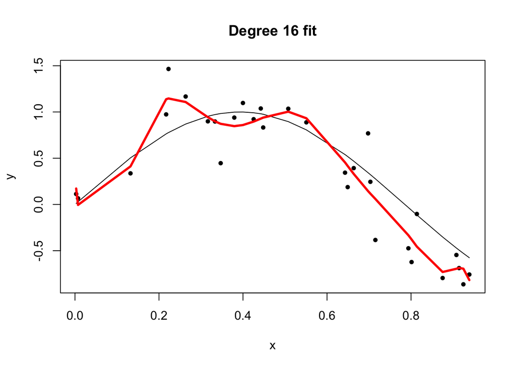

```
##   (Intercept)       power_1       power_2       power_3       power_4
##     0.2997561   -47.1252005   735.3737095 -3795.4717486  8115.6217984
##       power_5       power_6       power_7       power_8       power_9
## -4739.4903315 -5666.5561788  2839.1180051  6290.5078750  1898.1546570
##      power_10      power_11      power_12      power_13      power_14
## -3975.5435059 -5282.1463167 -1405.4547239  3420.9269326  4096.9927602
##      power_15      power_16
##  -341.3249926 -2152.9676333
```

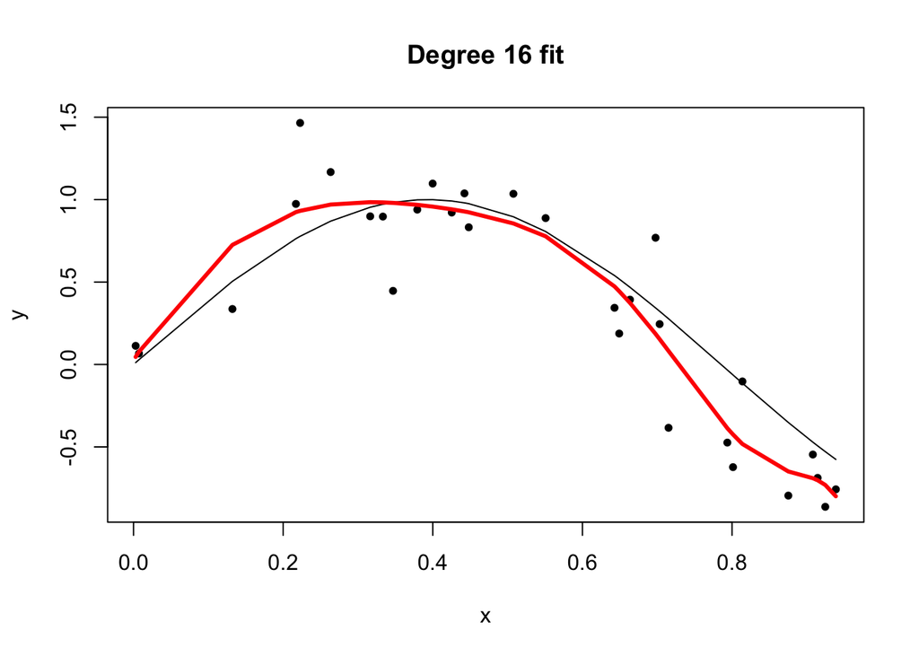

```
##  (Intercept)      power_1      power_2      power_3      power_4
##   0.02539043   7.23619782 -14.36367385  -7.07474649  35.41204386
##      power_5      power_6      power_7      power_8      power_9
##   5.22486035 -29.29709066 -32.16674692 -10.64606853  15.03213868
##     power_10     power_11     power_12     power_13     power_14
##  29.72807148  28.03142578  12.75967528  -7.98234227 -23.31129510
##     power_15     power_16
## -21.22704141  10.45659696
```

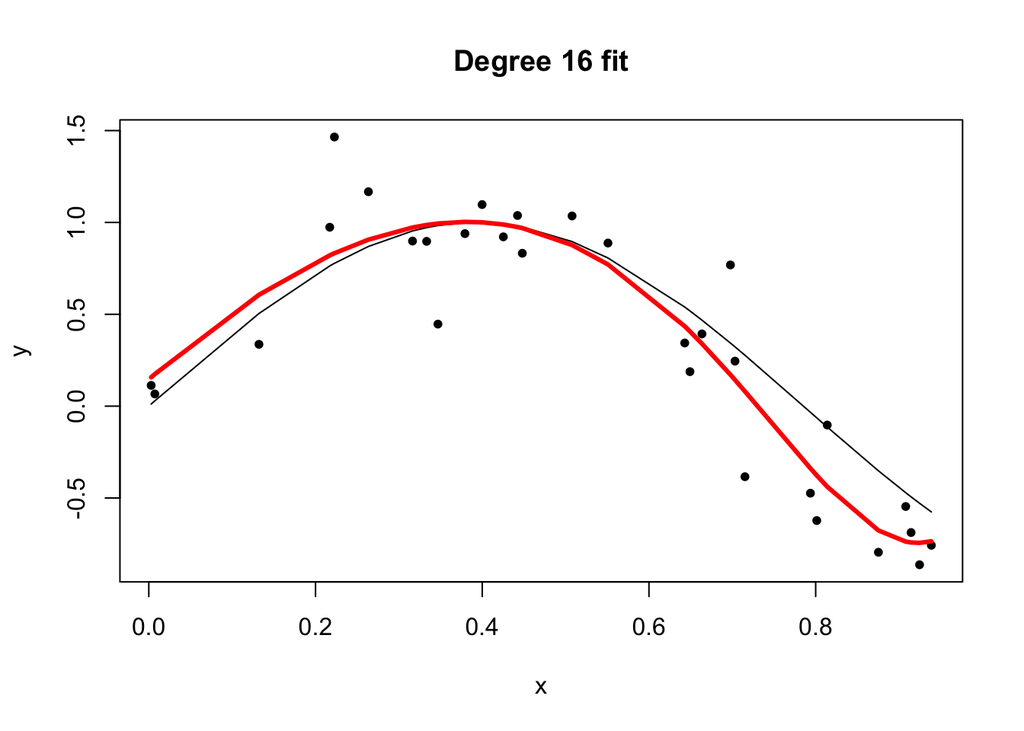

```
## (Intercept)     power_1     power_2     power_3     power_4     power_5
##   0.1457452   3.9822693  -3.4386357  -2.3837829  -1.1732197  -0.5209256
##     power_6     power_7     power_8     power_9    power_10    power_11
##  -0.1624399   0.1179510   0.3939992   0.6567724   0.8653747   0.9722501
##    power_12    power_13    power_14    power_15    power_16
##   0.9325289   0.7060510   0.2567047  -0.4489107  -1.4427726
```

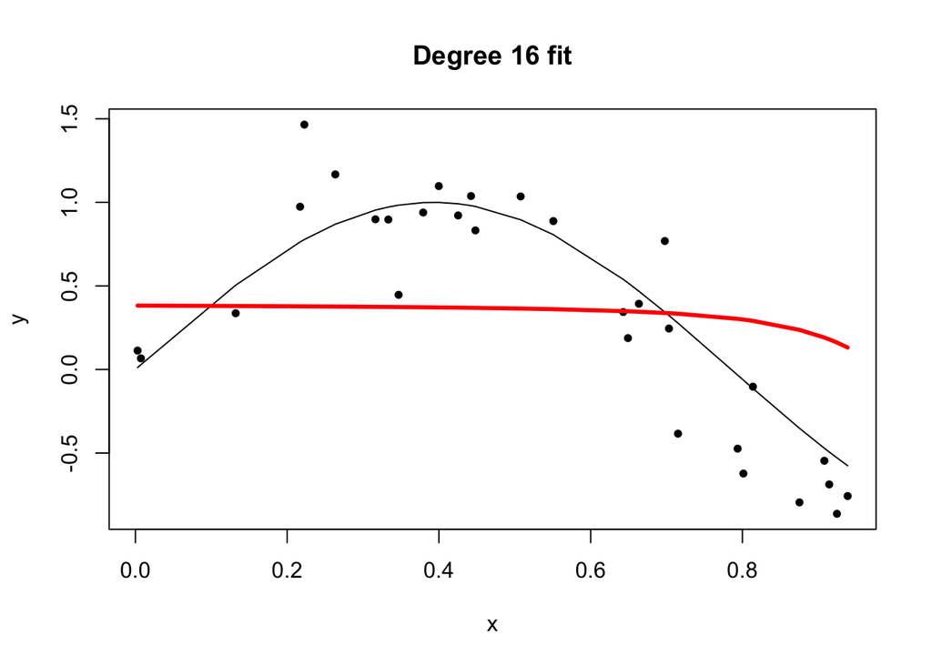

```
## (Intercept)     power_1     power_2     power_3     power_4     power_5
##  0.38220519 -0.01496566 -0.01731289 -0.01908541 -0.02069689 -0.02219452
##     power_6     power_7     power_8     power_9    power_10    power_11
## -0.02363228 -0.02506498 -0.02653743 -0.02808281 -0.02972504 -0.03148183
##    power_12    power_13    power_14    power_15    power_16
## -0.03336700 -0.03539221 -0.03756794 -0.03990423 -0.04241099
```